# homework_02

Esteban Jorquera; Marlon Aldair; Diego Ramírez

2022-02-28

# Practical: Alignment

```
# copies all files from its parent directory to a local work directory
cp /mnt/Timina/bioinfoII/data/alignment/* /mnt/Citosina/amedina/ejorquera/BioInfoII/Tarea_2

# opens a qlogin session
qlogin

# checks module availability
module avail

# loads a version (0.7.15) of the required program bwa, available from the module list
module load bwa/0.7.15

# loads a version (0.11.3) of the required program fastqc, available from the module list
module load fastqc/0.11.3

# loads a version (1.9) of the required program samtools, available from the module list
module load samtools/1.9
```

# E.Coli FNR ChIP-seq alignment

[output not shown]

## Analysis

#### fastqc FNR ChIP-seq results:

| Filename | File type | Encoding | Total Sequences | Sequences flagged as poor quality | Sequence length | %GC |
| --- | --- | --- | --- | --- | --- | --- |
| SRX189773_FNR_ChIP.fastq | Conventional base calls | Sanger / Illumina 1.9 | 3603544 | 0 | 36 | 49 |

According to fastqc results the FNR ChIP-seq basic statistics are correct

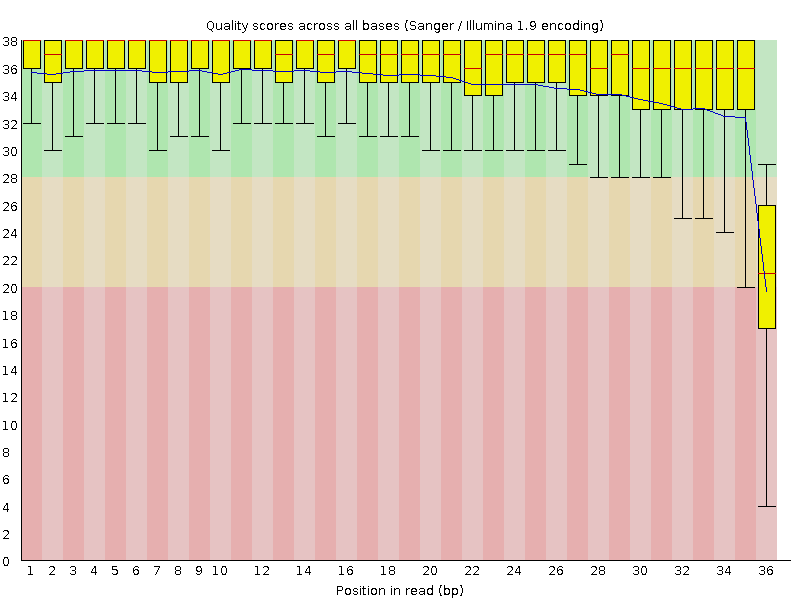

Similarly per base sequence quality remained consistent until the last base

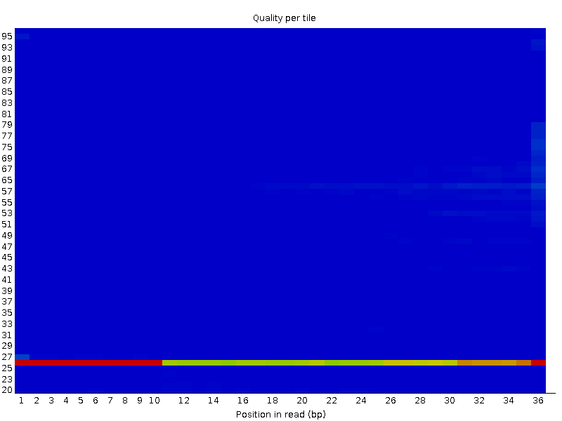

We see the first mayor issue in the per tile sequence quality, as seen in the lane #26, where sequence quality is lower than the rest of the flowcell, meanwhile this error could be transient (ie. bubbles forming in the flowcell), it seems that this lane might have been damaged since all positions of the reads of this lane have lower qualities.

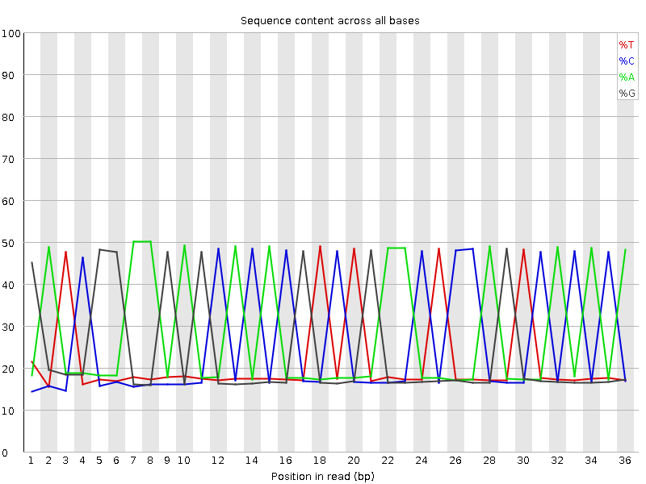

The next issue present is seen in the per base sequence content, here we should see similarly flat lines for every base, however we can see a clear preference of a base at a specific position, this indicates that a specific sequence was overrepressented, in this case the sequence we can read from the image is “GATCGGAAGAGCACACGTCTGAACTCCAGTCACACA”.Considering that this is a ChIP-seq experiment, we thought that this sequence could be the biding motif of the analyzed protein.

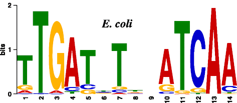

However, the “GATCGGAAGAGCACACGTCTGAACTCCAGTCACACA” sequence does not correspond to the binding motif of E.Coli FNR (Kumka & Bauer, 2015), meaning that the most likely cause of this error is the presence of sequencing adapters.

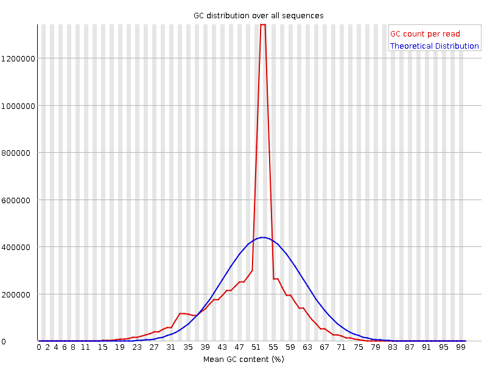

Guanine and Cytosine content also shows errors, indicating a large fraction of reads with GC content above the expected theoretical curve, at around 53% content, we suspect this is due to the overrepressented “GATCGGAAGAGCACACGTCTGAACTCCAGTCACACA” sequence.

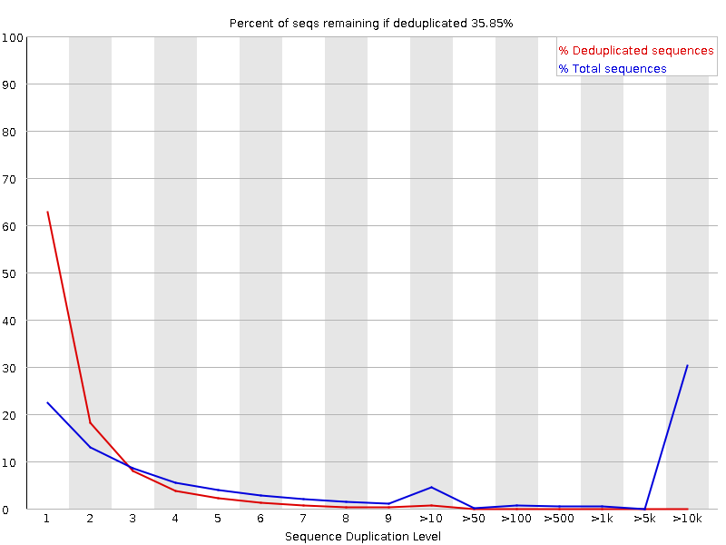

Regarding sequence duplication events we see that there are sequences that suffered extreme duplication events having more than 5000 duplication events, which likely correspond to the “GATCGGAAGAGCACACGTCTGAACTCCAGTCACACA” sequence and its variations

|  | Sequence | Count | Percentage | Possible Source |
| --- | --- | --- | --- | --- |
| FNR_seq_r1 | GATCGGAAGAGCACACGTCTGAACTCCAGTCACACA | 1060621 | 29.432719567181643 | TruSeq Adapter, Index 5 (100% over 36bp) |
| FNR_seq_r2 | GCTAACAAATACCCGACTAAATCAGTCAAGTAAATA | 13630 | 0.37823875606902535 | No Hit |
| FNR_seq_r3 | NATCGGAAGAGCACACGTCTGAACTCCAGTCACACA | 11728 | 0.3254573830651159 | TruSeq Adapter, Index 5 (97% over 36bp) |
| FNR_seq_r4 | GTTAGCTATTTACTTGACTGATTTAGTCGGGTATTT | 10983 | 0.304783291115635 | No Hit |
| FNR_seq_r5 | GATCGGAAGAGCACACGTCTGAACTCCAGTCACACC | 3658 | 0.10151117899490057 | TruSeq Adapter, Index 1 (97% over 36bp) |

When we analyze the overrepresented sequences, we can confirm that they correspond to adapters, specifically Illumina TruSeq adapters.

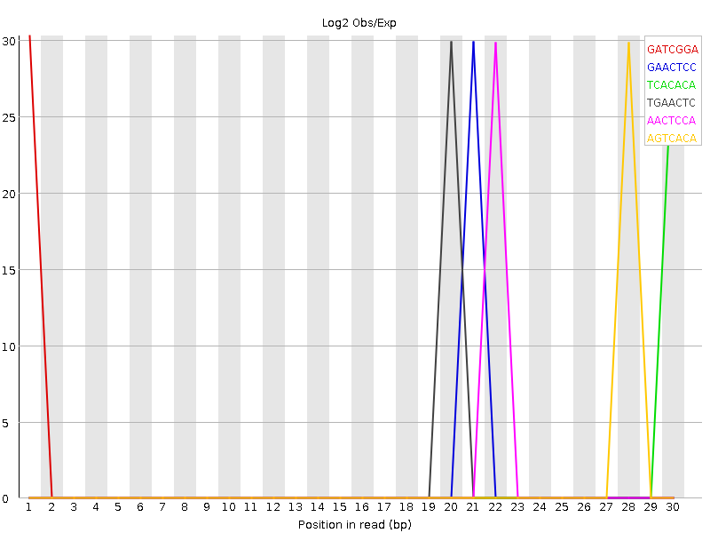

Finally, k-mer content profiles shows over-enrichment of specific sequences at certain positions, this is again likely caused by the presence of the Illumina TruSeq adapters in the dataset.

We strongly suggest to re-process the raw sequencing data using an adapter trimming software like Trimmomatic, and then re attempt the alignment

# M.Musculus CEBPA ChIP-seq alignment

Cluster location of processed mouse (mm10) reference genome and index files:

mm10 reference genome: /mnt/Archives/genome/mouse/mm10/UCSC/bwa-0.7.15-index/index/mm10.fa

mm10 index files: /mnt/Archives/genome/mouse/mm10/UCSC/bwa-0.7.15-index/index/mm10.fa.amb /mnt/Archives/genome/mouse/mm10/UCSC/bwa-0.7.15-index/index/mm10.fa.ann /mnt/Archives/genome/mouse/mm10/UCSC/bwa-0.7.15-index/index/mm10.fa.bwt /mnt/Archives/genome/mouse/mm10/UCSC/bwa-0.7.15-index/index/mm10.fa.pac /mnt/Archives/genome/mouse/mm10/UCSC/bwa-0.7.15-index/index/mm10.fa.sa

```
# executes fastqc for the compressed M.Musculus CEBPA (CCAAT/enhancer-binding protein alpha) transcription factor Chip-seq data file (mus_musculus_CEBPA_liver_ERR005132.fastq.gz)
fastqc /mnt/Citosina/amedina/ejorquera/BioInfoII/Tarea_2/mus_musculus_CEBPA_liver_ERR005132.fastq.gz -o output

# copies the html and compressed images output of fastqc for the CEBPA ChIP-seq data from the output folder located in the cluster into a local directory, so it can be easily opened
# fastqc compressed images output
scp ejorquera@dna.lavis.unam.mx:/mnt/Citosina/amedina/ejorquera/BioInfoII/Tarea_2/output/mus_musculus_CEBPA_liver_ERR005132_fastqc.zip /home/esteban/Tarea_2_Results
# fastqc html report
scp ejorquera@dna.lavis.unam.mx:/mnt/Citosina/amedina/ejorquera/BioInfoII/Tarea_2/output/mus_musculus_CEBPA_liver_ERR005132_fastqc.html /home/esteban/Tarea_2_Results
```

Considering the file sizes of both the mus musculus reference genome and the CEBPA ChIP-seq data, the memory available to qlogin sessions might not be enough, and would likely cause the process to hang indefinitely. Therefore a sge script was generated.

```
MMusculus.sge

#!/bin/bash
# Use current working directory
#$ -cwd
#
# Join stdout and stderr
#$ -j y
#
# Run job through bash shell
#$ -S /bin/bash
#
#You can edit the scriptsince this line
#
# Your job name
#$ -N Marlon_job

# Send an email after the job has finished
#$ -m e
#$ -M aldarchez26@gmail.com
#
# If modules are needed, source modules environment (Do not delete the next line):
. /etc/profile.d/modules.sh
#
# Add any modules you might require
(module load bwa/0.7.15 ; bwa mem -M -t 8 /mnt/Archives/genome/mouse/mm10/UCSC/bwa-0.7.15-index/index/mm10.fa /mnt/Timina/bioinfoII/data/alignment/mus_musculus_CEBPA_liver_ERR005132.fastq.gz > /mnt/Timina/bioinfoII/marciniega/tarea_02/MMusculus_FNR_ChIP.sam)
```

```
# runs the sge script to generate the CEBPA ChIP-seq data alignment in sam file format
qsub MMusculus.sge

# uses samtools stats to save  its output to a text file
samtools stats MMusculus_FNR_ChIP.sam > MMusculus_FNR_ChIP.stats

# loads samtools stats output into the nano text editor so it can be visualized
nano  MMusculus_FNR_ChIP.stats
```

## Analysis

#### fastqc CEBPA ChIP-seq results:

| Filename | File type | Encoding | Total Sequences | Sequences flagged as poor quality | Sequence length | %GC |
| --- | --- | --- | --- | --- | --- | --- |
| mus_musculus_CEBPA_liver_ERR005132.fastq.gz | Conventional base calls | Sanger / Illumina 1.9 | 17171130 | 0 | 42 | 45 |

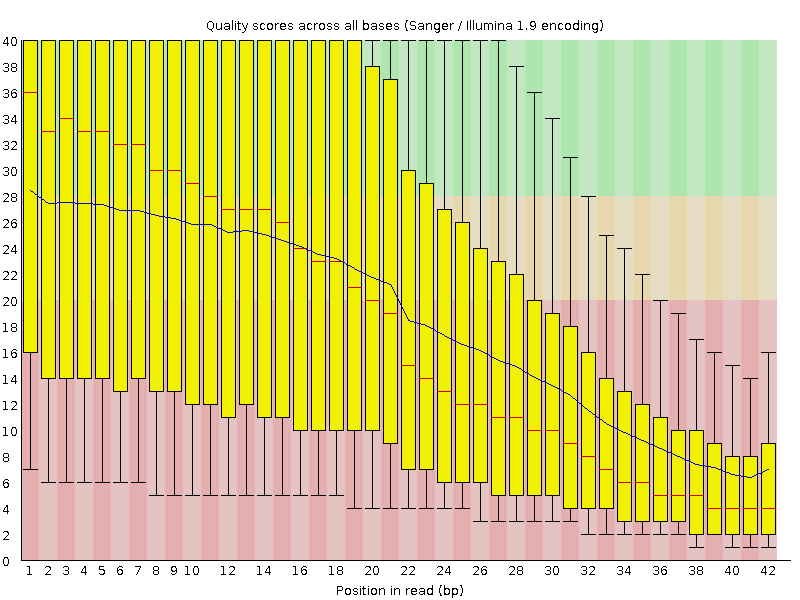

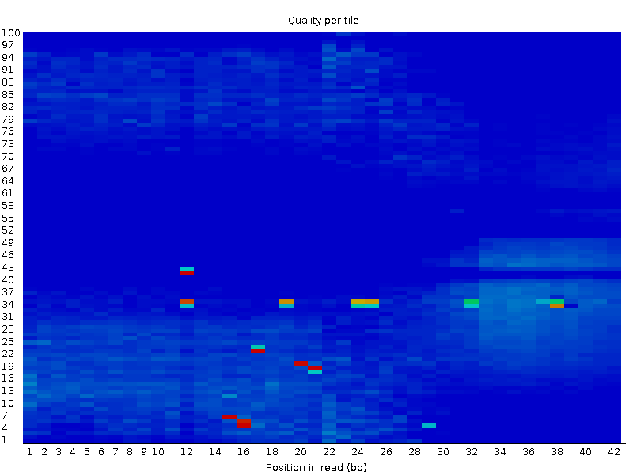

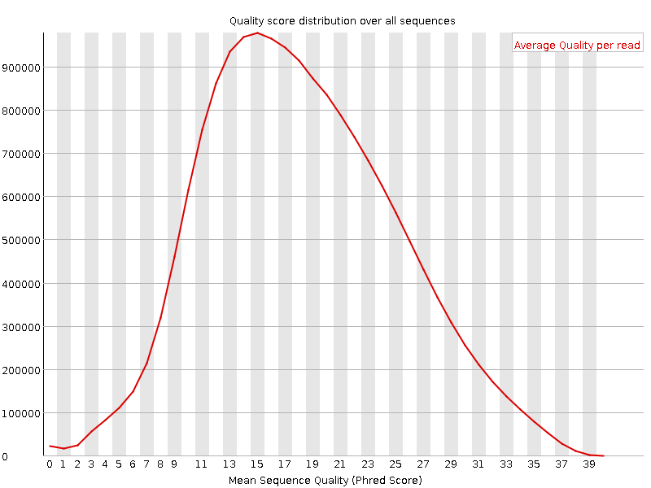

As we can see in the graph the mean sequence quality has its higher point around 15 with a like-normal distribution, which shows a low sequence quality (above 1% error rate) meaning that the base call accuracy rounds beetween 90-99%.

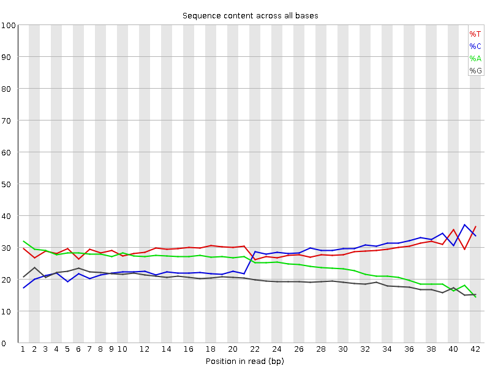

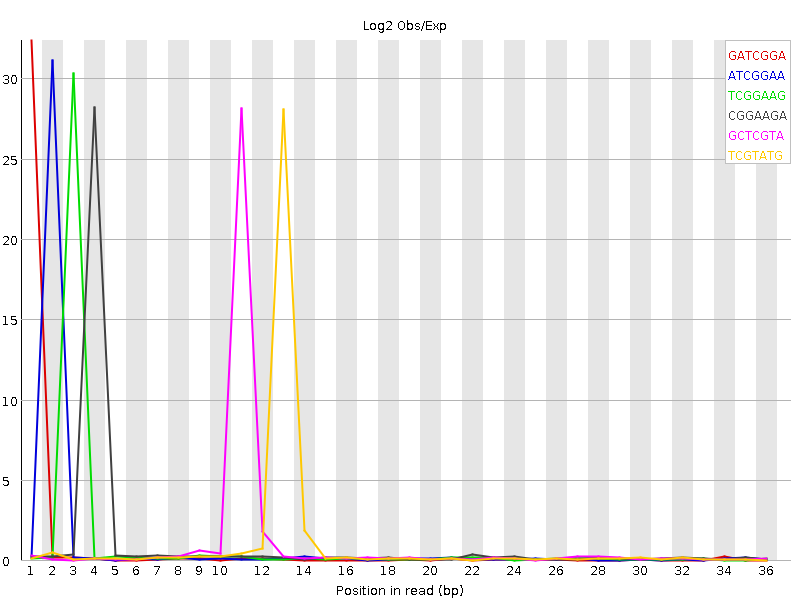